# Bestiary of Graphics

Here, we illustrate the variety of different graphs possible in R. These are all done with the base R install. Additional packages such as [lattice](http://statmethods.net/advgraphs/trellis.html) and [ggplot2](http://ggplot2.org/) provide more options and could be looked at once you are familiar with these.

### Examples of best (and worst) practice

[inspiration](http://www.datavis.ca/gallery/historical.php) | [despair …](http://www.datavis.ca/gallery/say-something.php)

*Functions:* hist(), barplot(), pie(), stripchart(), boxplot(), dotchart(), coplot()

*Packages:* vioplot, plotrix

*R code:* r code .txt

# Learning Goals

A. Foundational Knowledge

- Modify default plots using the graphical parameters function

B. Application

- Make plots according to specific spublisher or thesis requirements

C. Integration & Human Dimension

- Understand the presentation of data
- Consider how best to present your data to tell its story

## Data

Bird data.

```r
BirdData <- data.frame(
            Tarsus  = c(22.3, 19.7, 20.8, 20.3, 20.8, 21.5, 20.6, 21.5),
            Head    = c(31.2, 30.4, 30.6, 30.3, 30.3, 30.8, 32.5, 31.6),
            Weight  = c(9.5, 13.8, 14.8, 15.2, 15.5, 15.6, 15.6, 15.7),
            Wingcrd = c(59, 55, 53.5, 55, 52.5, 57.5, 53, 55),
            Species = c('A', 'A', 'A', 'A', 'A',  'B', 'B', 'B')
            )
```

# Graph Selection

Choosing the most appropriate graph for the data is one of the most important decisions you can make in presenting your results.

Here, we will look at some basic graphs, based on whether the x (predictor/independent variable) and y (response/dependent variable) are categorical or continuous:

1. Single continuous
2. Predictor and response are continuous
3. Single categorical
4. Categorical predictor and continous response

Stephen Few has a great [Graph Selection Matrix](https://www.perceptualedge.com/articles/misc/Graph_Selection_Matrix.pdf)

# The Bestiary

For each graph type, we will look at the default appearance and some of the more useful arguments we can alter.

# A single continuous variable, the histogram: hist()

**data:** single continuous variable

**use:** illustrating counts or distributions of data

**example:** bird data

[Histograms](https://en.wikipedia.org/wiki/Histogram) present the frequency (count) or probability density distribution of a vector of data.

- `breaks` describes the number of bins or breakpoints between bins.
- `freq = TRUE` defaults to counts; set to `FALSE` to plot probability distribution.
- `plot = TRUE` default will plot the histogram. Set to `FALSE` to not plot, and store the counts in an object for future use.

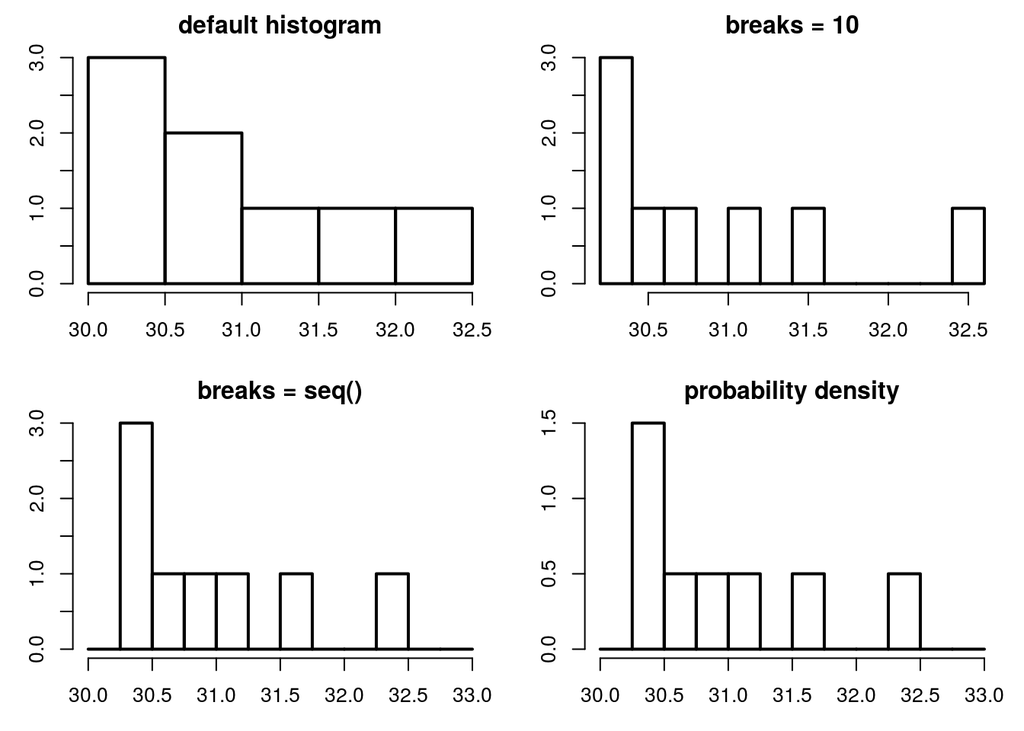

**Fig.** Some histograms

```r
# set layout and margins
par(mfrow = c(2, 2), mar = c(3, 3, 2, 1), lwd = 2)

hist(BirdData$Head, main = "default histogram")
hist(BirdData$Head, breaks = 10, main = "breaks = 10")
hist(BirdData$Head, breaks = seq(from = 30, to = 33, by = 0.25), main = "breaks = seq()" )

# plot probability density distribution
hist(BirdData$Head, breaks = seq(from = 30, to = 33, by = 0.25), freq = FALSE, main = "probability density" )
```

# Two continuous variables, predictor and response, the scatterplot / x-y plot: plot()

**data:** continuous response; continuous predictor.

**use:** illustrating relationships and correlations between continuous variables, …

**example:** BirdData

We have already used [scatter plots](https://en.wikipedia.org/wiki/Scatter_plot) (see Advanced Graphics.

Here, however, we add a legend to two of the panels, using `legend()`.

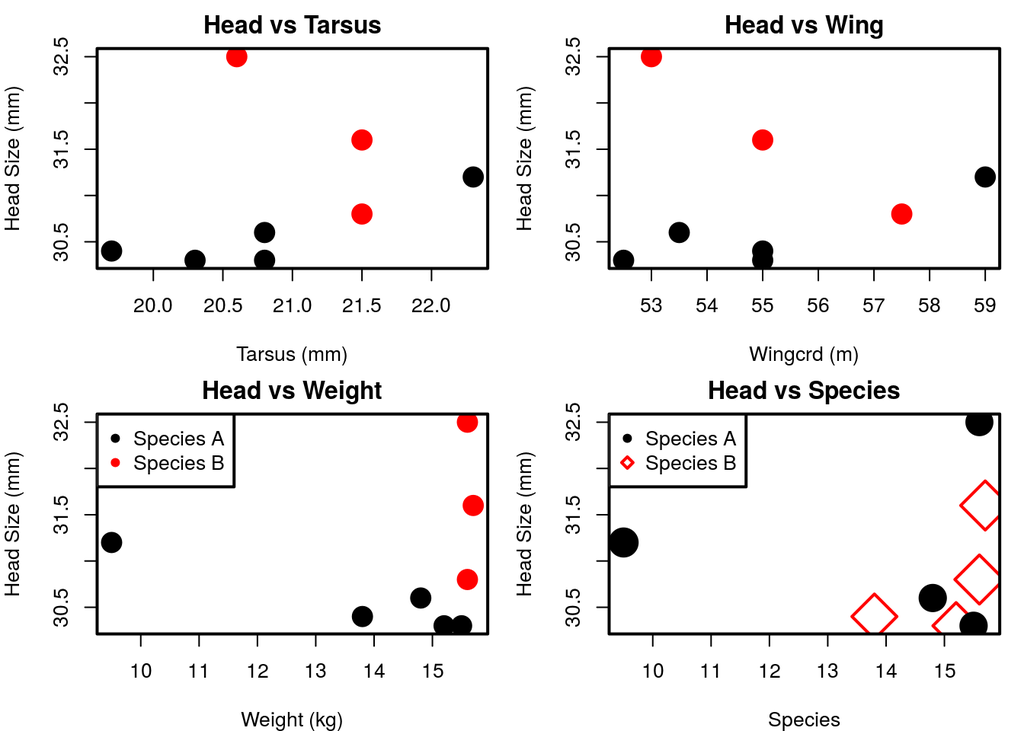

**Fig.** Some scatterplots

```r
par(mfrow = c(2, 2), mar = c(4, 4, 2, 1), lwd = 2)

plot(Head ~ Tarsus, data = BirdData,
     xlab = 'Tarsus (mm)',
     ylab = 'Head Size (mm)',
     main = 'Head vs Tarsus',
     pch = 20,
     col = Species,
     cex = 3)

plot(Head ~ Wingcrd, data = BirdData,
     xlab = 'Wingcrd (m)',
     ylab = 'Head Size (mm)',
     main = 'Head vs Wing',
     pch = 20,
     col = Species,
     cex = 3)

plot(Head ~ Weight, data = BirdData,
     xlab = 'Weight (kg)',
     ylab = 'Head Size (mm)',
     main = 'Head vs Weight',
     pch = 20,
     col = Species,
     cex = 3)
# Here, we add a legend to this plot
  legend('topleft',
         pch = c(20, 20), col = c(1, 2),
         legend = c('Species A', 'Species B')
        )

plot(Head ~ Weight, data = BirdData,
     xlab = 'Species',
     ylab = 'Head Size (mm)',
     main = 'Head vs Species',
     pch = c(20, 23),
     col = 1:2,
     cex = Tarsus/5)
# Another legend
  legend('topleft',
         pch = c(20, 23), col = c(1, 2),
         legend = c('Species A', 'Species B')
        )
```

# Categorical predictor/independent variable

## The pie chart: pie()

A [pie chart](https://en.wikipedia.org/wiki/Pie_chart) is a circular representation of counts or proportion, with the angle corresponding to the value of each category.

**data**: usually counts or proportion response; categorical predictor

**use:** never! (unless it involves [real pie](http://data1.whicdn.com/images/112306/20080913043158_large.jpg))

**example:** BirdFlu

We have annual data from the years 2003-2008. Has the total number of bird flu cases has increased over time?

Load the data and select only cases columns.

```r
BFdata <- read.table(file = 'http://www.simonqueenborough.info/R/basic/data/birdflu_corrected.txt', header = TRUE, sep = '\t')
# select cases columns only
BFcases <- BFdata[, c('cases03', 'cases04', 'cases05', 'cases06', 'cases07', 'cases08')]
names(BFdata)
```

```
##  [1] "Country"  "cases03"  "deaths03" "cases04"  "deaths04" "cases05"
##  [7] "deaths05" "cases06"  "deaths06" "cases07"  "deaths07" "cases08"
## [13] "deaths08"
```

```r
str(BFdata)
```

```
## 'data.frame':    15 obs. of  13 variables:
##  $ Country : Factor w/ 15 levels "Azerbaijan","Bangladesh",..: 1 2 3 4 5 6 7 8 9 10 ...
##  $ cases03 : int  0 0 0 1 0 0 0 0 0 0 ...
##  $ deaths03: int  0 0 0 1 0 0 0 0 0 0 ...
##  $ cases04 : int  0 0 0 0 0 0 0 0 0 0 ...
##  $ deaths04: int  0 0 0 0 0 0 0 0 0 0 ...
##  $ cases05 : int  0 0 4 8 0 0 20 0 0 0 ...
##  $ deaths05: int  0 0 4 5 0 0 13 0 0 0 ...
##  $ cases06 : int  8 0 2 13 1 18 55 3 0 0 ...
##  $ deaths06: int  5 0 2 8 0 10 45 2 0 0 ...
##  $ cases07 : int  0 0 1 5 0 25 42 0 2 1 ...
##  $ deaths07: int  0 0 1 3 0 9 37 0 2 0 ...
##  $ cases08 : int  0 1 0 3 0 7 18 0 0 0 ...
##  $ deaths08: int  0 0 0 3 0 3 15 0 0 0 ...
```

Now we make a vector of the sum of each year’s cases using `colSums()`, and add names to each element using `names()`.

```r
Cases <- colSums(BFcases)
names(Cases) <- 2003:2008
Cases
```

```
## 2003 2004 2005 2006 2007 2008
##    4   46   98  115   88   34
```

The `pie()` function requires a vector of non-negative integers. The names associated with each element are added as labels.

The default direction of `pie()` is anti-clockwise. This can be reversed setting `clockwise = TRUE` (the second pie chart).

For those who will sink so low, there is also a 3-D pie chart function in the ‘plotrix’ package…

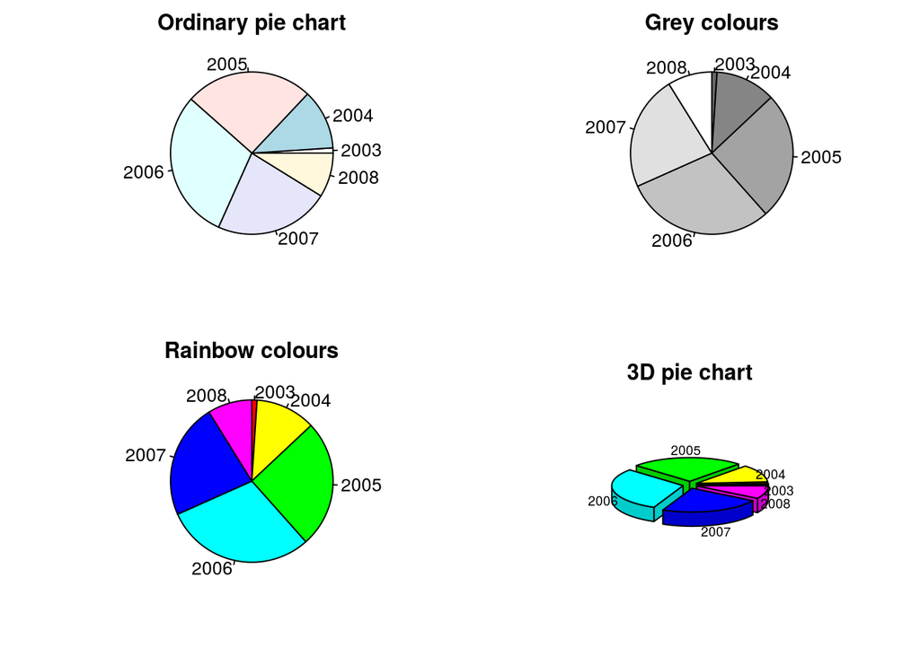

**Fig**. Some pie charts

```r
par(mfrow = c(2, 2), mar = c(3, 3, 2, 1))
pie(Cases, main = "Ordinary pie chart")
pie(Cases, col = gray(seq(0.4, 1.0, length = 6)), clockwise = TRUE, main = "Grey colours")
pie(Cases, col = rainbow(6), clockwise = TRUE, main = "Rainbow colours")
#install.packages('plotrix')
library(plotrix)
pie3D(Cases, labels = names(Cases), explode = 0.1, main = "3D pie chart", labelcex = 0.6)
```

#### A word of caution

Most professional statistical graphicicians recommend against using pie charts for the following reasons:

1. Values of all categories need to sum to a meaningful whole
2. Categories need to be mutually exclusive
3. Category ‘other’ may hide important information
4. It is hard for the human eye to measure angles, and therefore the size of each slice
5. Pie charts often require extra labels and legends to interpret (low data:ink ratio)

See [here](http://eagereyes.org/techniques/pie-charts) for a greater discussion of these issues.

## The stacked bar plot (better than a pie chart)

An improvement on the pie chart is the stacked bar plot. This allows the viewer to more readily compare the sizes of each section because we also have an axis. But.. there are no labels (although we could add them with `text()` or `legend()`).

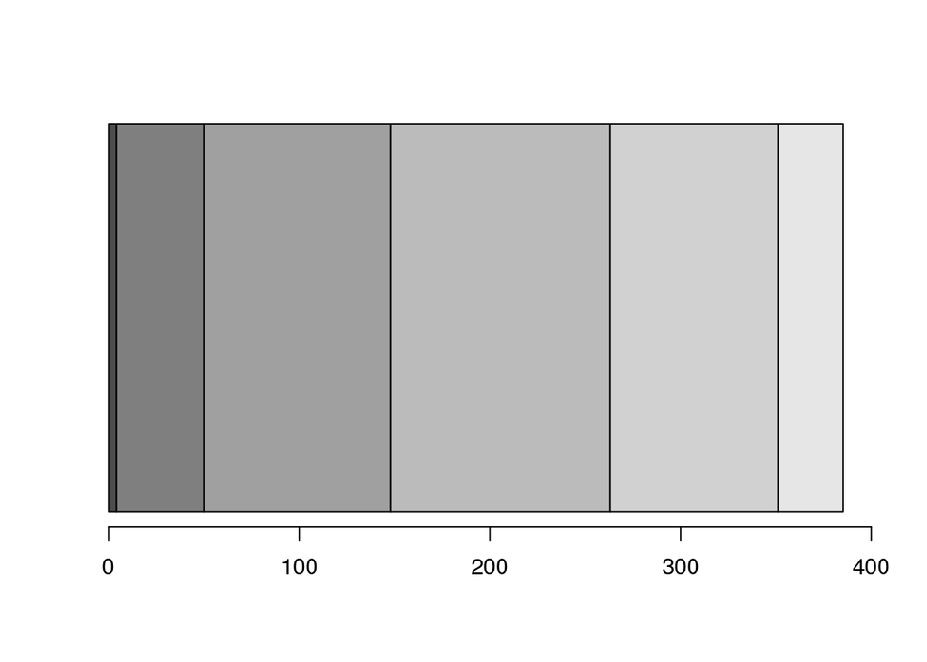

An improvement to the pie chart, the stacked bar plot

```r
# To get the 'stacked' bars, we need to convert our vector to a matrix (barplot() will only stack a matrix).
barplot(as.matrix(Cases), horiz = TRUE, xlim = c(0, 400))
```

The `barplot()` function is discussed in more detail below.

# Categorical predictor/independent variable and continous response variable

There are a variety of ways to plot continuous data as a function of categorical predictors.

## If your response data are counts, use a bar chart: barplot()

**data:** continuous or count response; categorical or binned continuous predictor

**use:** comparing categories, showing distributions, …

**example:** BirdFluDeath

We use the bird flu data again, but this time select the deaths columns.

```r
BFdata <- read.table(file = 'http://www.simonqueenborough.info/R/basic/data/birdflu_corrected.txt', header = TRUE, sep = '\t')
# select cases columns only
BFdeaths <- BFdata[, c('deaths03', 'deaths04', 'deaths05', 'deaths06', 'deaths07', 'deaths08')]
names(BFdeaths)
```

```
## [1] "deaths03" "deaths04" "deaths05" "deaths06" "deaths07" "deaths08"
```

```r
str(BFdeaths)
```

```
## 'data.frame':    15 obs. of  6 variables:
##  $ deaths03: int  0 0 0 1 0 0 0 0 0 0 ...
##  $ deaths04: int  0 0 0 0 0 0 0 0 0 0 ...
##  $ deaths05: int  0 0 4 5 0 0 13 0 0 0 ...
##  $ deaths06: int  5 0 2 8 0 10 45 2 0 0 ...
##  $ deaths07: int  0 0 1 3 0 9 37 0 2 0 ...
##  $ deaths08: int  0 0 0 3 0 3 15 0 0 0 ...
```

```r
# Make a vector as before
Deaths <- colSums(BFdeaths)
names(Deaths) <- 2003:2008
Deaths
```

```
## 2003 2004 2005 2006 2007 2008
##    4   32   43   79   59   26
```

How have the number of cases and deaths changed over time?

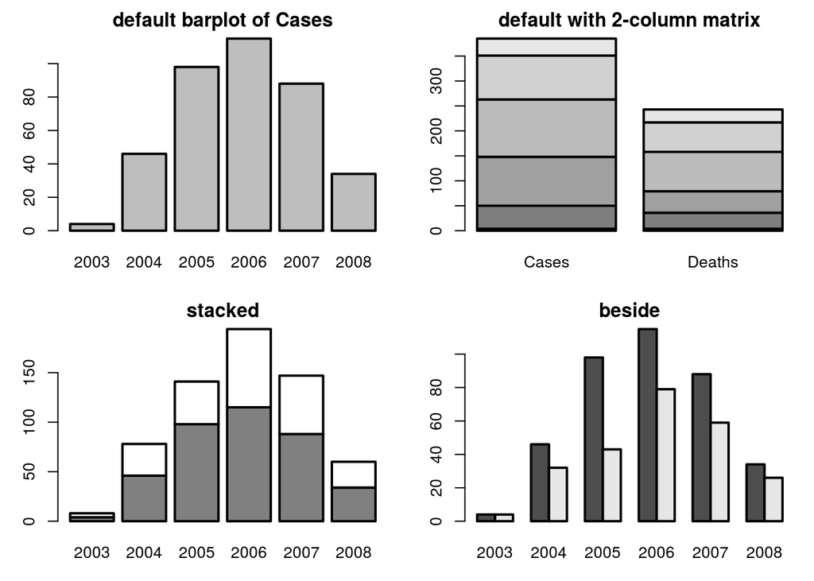

**Fig.** Some bar plots

```r
par(mfrow = c(2, 2), mar = c(3, 3, 2, 1), lwd = 2)
barplot(Cases, main = "default barplot of Cases")

# Create a new variable
Counts <- cbind(Cases, Deaths) # makes a matrix
barplot(Counts, main = "default with 2-column matrix" )
barplot(t(Counts), col = gray(c(0.5, 1)), main = "stacked")
barplot(t(Counts), beside = TRUE, main = "beside")
```

## If your response data are continuous, also use a bar chart, but add error bars: barplot()

First, we need to calculate the mean and standard deviation values for bird heads of each species.

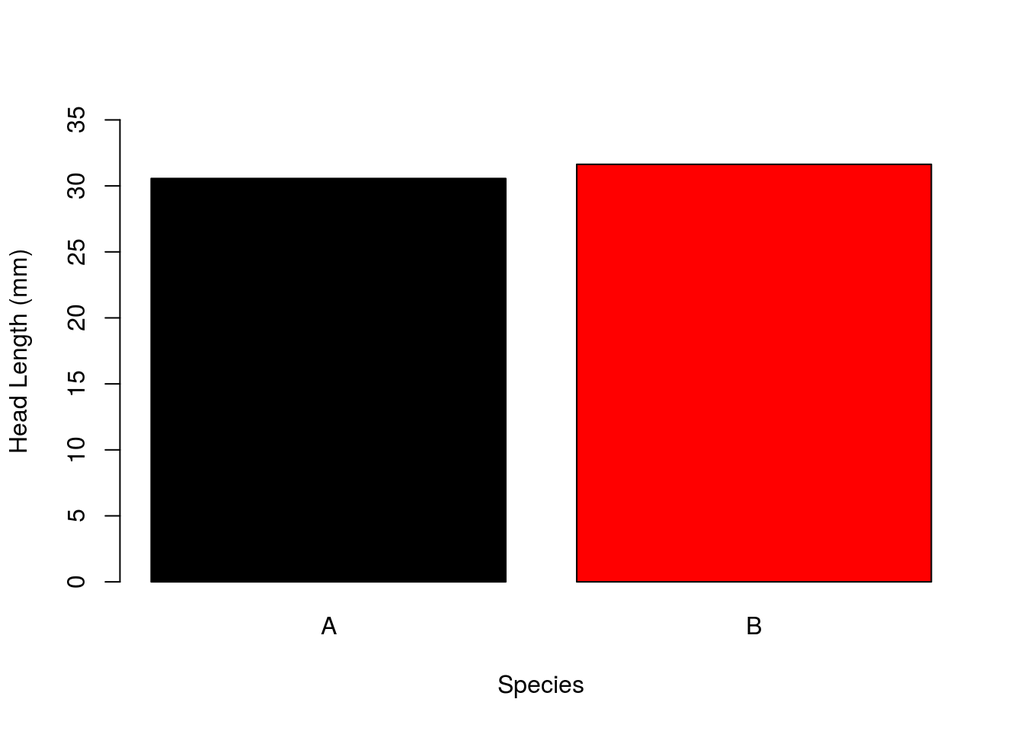

Bird head without error bars

```r
head.mean <- tapply(BirdData$Head, INDEX = BirdData$Species, FUN = mean)
head.sd <- tapply(BirdData$Head, INDEX = BirdData$Species, FUN = sd)

barplot(head.mean,
        xlab = "Species", ylab = "Head Length (mm)",
        ylim = c(0, 35),
        col = 1:2)
```

Then we can plot the data and add error bars.

There are two options for creating error bars: `arrows()` and `segments()`. Both work in a similar way, drawing lines between two coordinates. For vertical error bars, you keep the x coords the same for each line, and for horizontal error bars keep the y coords the same. `arrows()` adds an arrow head to one end of the line, and you can set the `angle` to 90 degrees so that it is a flat arrow. As usual, the coordinate arguments `x0`, `y0`, `x1` and `y1` can take single values or vectors.

We first need to determine the x values for the lines. This is done by assigning the `barplot()` output to an object and then calling that. This saves the values of the midpoints of each bar.

```r
xvals <- barplot(head.mean, plot = FALSE)
xvals
```

```
##      [,1]
## [1,]  0.7
## [2,]  1.9
```

We can then add the arrows to the bar plot.

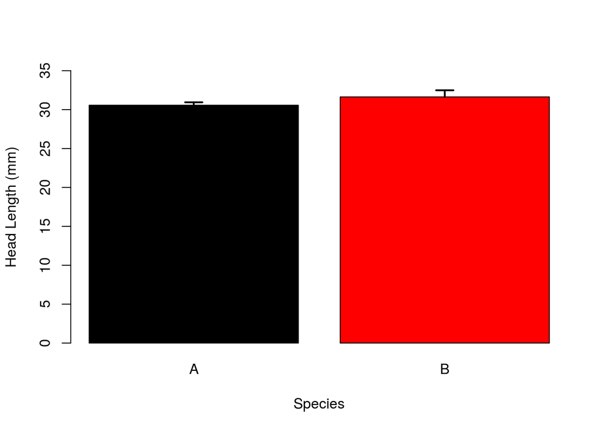

Bird head with error bars

```r
barplot(head.mean,
        xlab = "Species", ylab = "Head Length (mm)",
        ylim = c(0, 35),
        col = 1:2)

arrows(x0 = xvals, y0 = head.mean,      # arrow from ...
       x1 = xvals, y1 = head.mean + head.sd,  #  ... to
       lwd = 2, angle = 90, length = 0.1)
```

The function `segments()` works in an identical fashion, but has no arrow head.

Bar plots are fine, but are limited in that they do not display much of the raw data, and use a lot of ink to convey that small amount of information. There are other plots that show more of the data.

## box plot: boxplot()

To provide the viewer with a much better idea of the distribution of your data, a [boxplot](https://en.wikipedia.org/wiki/Box_plot) can be used.

**data:** continuous response; categorical predictor

**use:**

- detection of outliers
- displays heterogeneity of distributions
- effects of predictor variables

**example:** Bird data

We already used `plot()` to make a box plot. However, the function `boxplot()` has more arguments and we can modify the appearance much more.

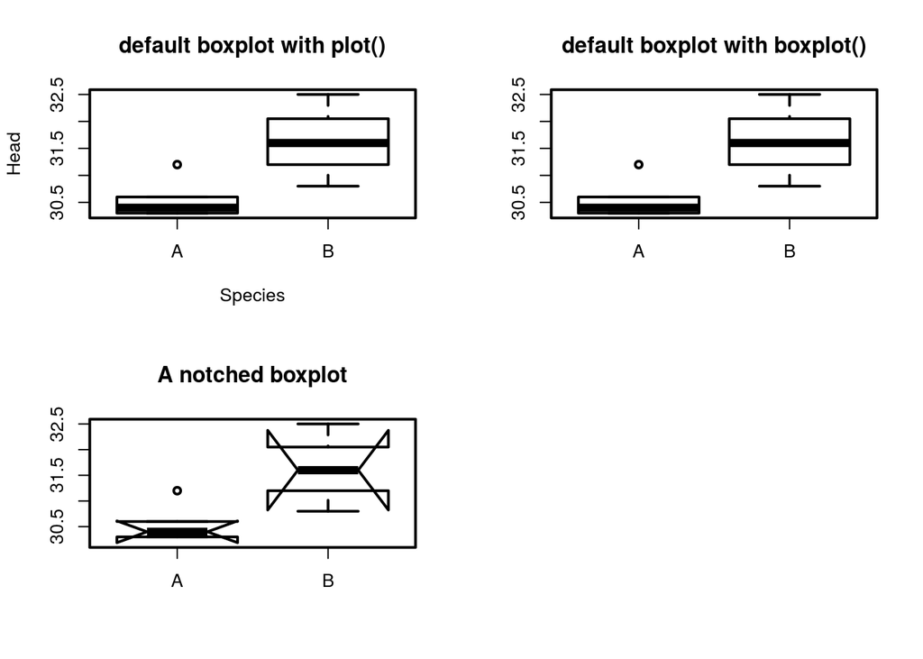

**Fig.** Some box plots

```r
par(mfrow = c(2, 2), lwd = 2)

plot(Head ~ Species,
     data = BirdData,
     main = "default boxplot with plot()")

boxplot(Head ~ Species,
        data = BirdData,
        main = "default boxplot with boxplot()")


boxplot(Head ~ Species,
        data = BirdData,
        notch = TRUE,
        main = "A notched boxplot")
# install.packages('vioplot')
library(vioplot)

bird.A <- BirdData$Head[BirdData$Species == 'A']
bird.B <- BirdData$Head[BirdData$Species == 'B']

#vioplot(bird.A, bird.B)

#mtext(side = 3, text = "default violin plot", line = 1.8, font = 2)
```

## Display raw and summary data: stripchart()

Graphical best practice is to show both raw data and summary data if possible. The `stripchart()` function can be used to do just that.

**data:** continuous response; categorical predictor

**use:** differences between categories, plotting raw data and summary data on top

**example:** BirdData

The default plots all data on one line, therefore we need to set `method = 'jitter'` to add some random y-axis variation to each point to show the raw data more clearly.

Using the mean and standard deviations we calculated before, we can then use `points()` and `arrows()` to add the summary data on top.

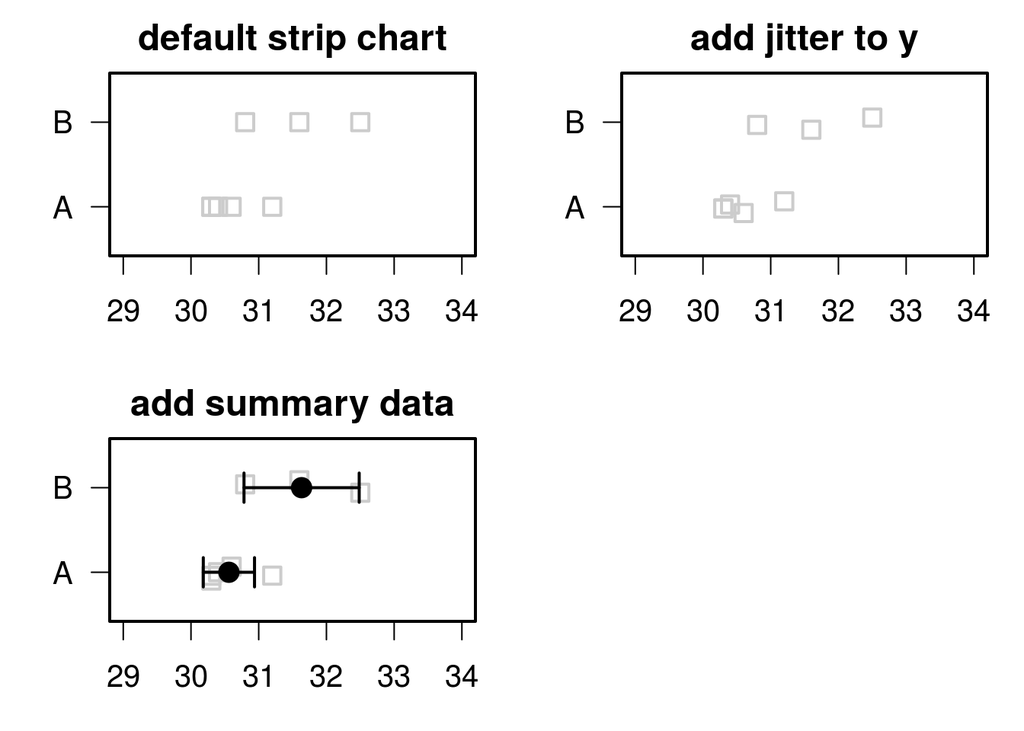

**Fig.** Some strip charts

```r
par(mfrow = c(2, 2), mar = c(3, 3, 2, 1), lwd = 2, las = 1, cex = 1.25)

stripchart(BirdData$Head ~ BirdData$Species,
           xlim = c(29, 34), ylim = c(0.5, 2.5),
           main = "default strip chart",
           col = 'grey80')

stripchart(BirdData$Head ~ BirdData$Species,
           xlim = c(29, 34), ylim = c(0.5, 2.5),
           main = "add jitter to y",
           col = 'grey80',
           method = 'jitter')

stripchart(BirdData$Head ~ BirdData$Species,
           xlim = c(29, 34), ylim = c(0.5, 2.5),
           main = "add summary data",
           col = 'grey80',
           method = 'jitter')

  points(x = head.mean, y = 1:2, pch = 20, cex = 2)
  arrows(x0 = head.mean, y0 = 1:2,
         x1 = head.mean + head.sd, y1 = 1:2,
         angle = 90, length = 0.1, lwd = 2)
  arrows(x0 = head.mean, y0 = 1:2,
         x1 = head.mean - head.sd, y1 = 1:2,
         angle = 90, length = 0.1, lwd = 2)
```

# Resources

There are many other possibilities for graphics, depending on the nature of your data and what you want to show of it.

## websites

http://blog.revolutionanalytics.com/2009/01/10-tips-for-making-your-r-graphics-look-their-best.html

Gallery of [Data Visualisation](http://www.datavis.ca/gallery/index.php)

[Quick R](http://statmethods.net/graphs/)

[R Cook Book](http://www.cookbook-r.com/Graphs/)

[R wiki book](https://en.wikibooks.org/wiki/R_Programming/Graphics)

[R Graph Gallery](http://www.r-graph-gallery.com/)

## Books

[R Graphics](https://www.stat.auckland.ac.nz/~paul/RGraphics/rgraphics.html) - full details of base R graphics capabilities

Updated: 2016-10-05